# Project proposal

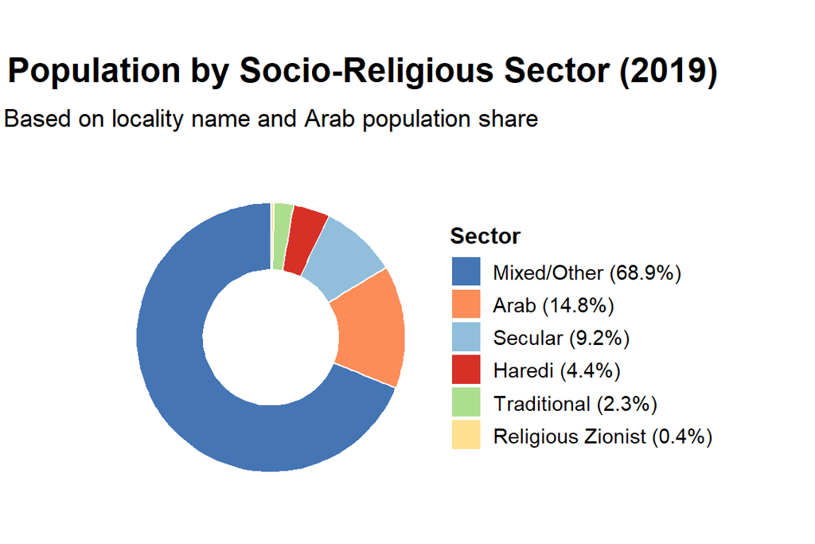

This chart presents the socio-religious distribution of Israel’s population in 2019, categorized by locality type and Arab population share. The largest segment (68.9%) resides in mixed or non-sectorial areas. Arab-majority localities comprise 14.8%, while secular Jewish communities make up 9.2%. Smaller but distinct groups include Haredi (4.4%), Traditional (2.3%), and Religious Zionist (0.4%) sectors. This breakdown provides key demographic context for analyzing social and civic patterns across the country.

## 4. Data analysis plan

The main response variable in our research is the divorce rate per city, calculated as the number of divorced individuals divided by the total relevant population. To discover the causes of the divorce rate we can check multiple parameters such as: Demographic structure - the proportion of children, young adults, and elderly residents, Educational background - distinguishing between academic and non-academic populations, Employment indicators - distinguishing between employment and unemployment rates, Sociocultural composition - the distribution of religious, Arab, and other population groups, Election results - reflect the political preferences and cultural values in each city. To further investigate the data, we plan to use multivariable regression models to assess the relative effect of each predictor, as well as classification models to identify key patterns. Our goal is to identify one variable—or a small set of variables—with a strong and consistent influence on divorce rates, helping us uncover the dominant factors that explain most of the variation across cities. All team members will work together on every stage of the project — from data preparation to analysis and writing. We plan to meet regularly in person, as we believe that joint discussion and face-to-face teamwork are more efficient and productive to us.

## Appendix

### Data README

```
# README

This file describes the meaning of each column used in the project datasets.

### divorces_city.csv

| Column Name | Description |
|-------------|-------------|
| `locality` | שם העיר |
| `divorces_sum` | מספר הזוגות שהתגרשו |
| `year` | שנה |

### population_2019.csv

| Column Name | Description |
|-------------|-------------|
| `English name` | עיר מוצא |
| `total_population` | סה"כ אוכלוסיה |
| `Jews and Others` | יהודים ואחרים |
| `Jews` | יהודים |
| `Others` | דתות אחרות |
| `Arabs` | ערבים |

### Married_Divorced.xlsx

| Column Name | Description |
|-------------|-------------|
| `Stillbirths` | לידות שקטות |
| `Infant deaths` | מקרי מוות של תינוקות |
| `Natural increase` | ריבוי טבעי |
| `Deaths` | מוות |
| `Live births` | לידות חיות (רגילות) |
| `Divorces` | גירושין |
| `Marriages` | נישואין |
| `Year` | שנה |

### Age_city_2019.csv

| Column Name | Description |
|-------------|-------------|
```

[output cut: 23 more lines]

```
| `Hh` | מספר משקי הבית בישוב |
| `Unemployed job seekers` | מובטלים מחפשי עבודה |
| `Placement from reference` | מספר האנשים שהושמו בעבודה דרך לשכת התעסוקה |
| `Estimated unemployed rate in city` | אחוז אבטלה מוערך |

### Election_2019.csv

| Column Name | Description |
|-------------|-------------|
| `locality` | ישוב |
| `eligible_voters` | זכאים לבחור |
| `total_votes` | סה"כ הצבעות |
| `invalid_votes` | הצבעות לא חוקיות |
| `valid_votes` | הצבעות חוקיות |
All of the other columns are parties names.
```

### Source code

```r
library(knitr)
library(tidyverse)
library(broom)
library(htmltools)
library(readxl)
library(dplyr)
library(ggplot2)
library(sf)
library(janitor)
library(tidyr)
options(warn = -1)
opts_chunk$set(echo=FALSE) # hide source code in the document
knitr::opts_chunk$set(fig.width = 5, fig.height = 3)
age_city <- read.csv("data/Age_city_2019.csv", fileEncoding = "Windows-1255")
divorces_city <- read.csv("data/divorces_city.csv", fileEncoding = "UTF-8")
election_city <- read.csv("data/Election_2019.csv", fileEncoding = "Windows-1255")
populations_city <- read.csv("data/population_2019.csv", fileEncoding = "UTF-8")
population_B_T <- read.csv("data/Population_TelAviv_BneiBrak_2003_2022.csv", fileEncoding = "UTF-8")
demographic_city <- read_excel("data/Demographic_info.xlsx")
married_divorced <- read_excel("data/Married_Divorced.xlsx")
israel_map <- st_read("data/places/places.shp")
israel_shape <- st_read("data/places/places.shx")
map_population <- read.csv("data/population_HB_2019.csv", fileEncoding = "UTF-8")
divorces_2019 <- divorces_city %>%
  filter(year == 2019)

merged_data <- left_join(divorces_2019, map_population, by = "locality") %>%
  mutate(divorces_per_1000 = (divorces_sum / total_population) * 1000)

divorce_map_data <- merged_data %>%
  select(locality, divorces_per_1000) %>%
  rename(name = locality)

places_joined <- left_join(israel_map, divorce_map_data, by = "name")

ggplot() +
  geom_sf(data = israel_shape, color = "gray", size = 0.2) +
  geom_sf(
    data = filter(places_joined, is.na(divorces_per_1000)),
    color = "grey85", size = 1, alpha = 0.1
  ) +
  geom_sf(
    data = filter(places_joined, !is.na(divorces_per_1000)),
    aes(color = divorces_per_1000),
    size = 1.5
  ) +
  scale_color_gradient(low = "pink", high = "darkred") +
  labs(
    title = "Divorces per 1000 People by City (2019)",
    color = "Divorces per 1000"
  ) +
  theme_minimal()
df_clean <- married_divorced%>%
  select(Year = 8, Divorces = 6, Marriages = 7) %>%
  filter(!is.na(Year) & !is.na(Divorces) & !is.na(Marriages))

df_clean$Divorces <- as.numeric(gsub(",", "", df_clean$Divorces))
df_clean$Marriages <- as.numeric(gsub(",", "", df_clean$Marriages))
df_clean$Year <- as.numeric(df_clean$Year)

df_clean <- df_clean %>%
  filter(!is.na(Marriages) & !is.na(Divorces) & !is.na(Year))

df_filtered <- df_clean %>% filter(Year >= 2013 & Year <= 2022)

ggplot(df_filtered, aes(x = Year, y = Marriages)) +
  geom_point(color = "steelblue", size = 3) +
  geom_smooth(method = "lm", se = FALSE, color = "black", linewidth = 1.2) +
  labs(title = "Marriage Trend in Israel (2013–2022)",
       x = "Year", y = "Number of Marriages") +
  theme_minimal(base_size = 14) +
  theme(plot.title = element_text(hjust = 0.5))

ggplot(df_filtered, aes(x = Year, y = Divorces)) +
  geom_point(color = "darkorange", size = 3) +
  geom_smooth(method = "lm", se = FALSE, color = "black", linewidth = 1.2) +
  labs(title = "Divorce Trend in Israel (2013–2022)",
       x = "Year", y = "Number of Divorces") +
  theme_minimal(base_size = 14) +
  theme(plot.title = element_text(hjust = 0.5))
sector_summary <- data.frame(
  sector = c("Mixed/Other", "Arab", "Secular", "Haredi", "Traditional", "Religious Zionist"),
  percent = c(68.9, 14.8, 9.2, 4.4, 2.3, 0.4)
) %>%
  arrange(desc(percent)) %>%
  mutate(
    fraction = percent / 100,
    ypos = cumsum(fraction) - 0.5 * fraction,
    sector = factor(sector, levels = sector)
  )
custom_colors <- c(
  "Mixed/Other" = "#4575b4",
  "Arab" = "#fc8d59",
  "Secular" = "#91bfdb",
  "Haredi" = "#d73027",
  "Traditional" = "#addd8e",
  "Religious Zionist" = "#fee090"
)

p <- ggplot(sector_summary, aes(x = 2, y = fraction, fill = sector)) +
  geom_col(width = 1, color = "white", linewidth = 0.5) +
  coord_polar("y", start = 0) +
  xlim(0.5, 2.5) +

  scale_fill_manual(
    values = custom_colors,
    name = "Sector",
    labels = paste0(sector_summary$sector, " (", sector_summary$percent, "%)")
  ) +

  labs(
    title = "                    Population by Socio-Religious Sector (2019)",
    subtitle = "Based on locality name and Arab population share"
  ) +

  theme_void() +
  theme(
    plot.title = element_text(size = 18, face = "bold", hjust = 0.5, margin = margin(t = 30, b = 10)),
    plot.subtitle = element_text(size = 13, hjust = 0.5, margin = margin(b = 20)),
    legend.position = "right",
    legend.title = element_text(size = 12, face = "bold"),
    legend.text = element_text(size = 11),
    plot.margin = margin(t = 0, r = 20, b = 20, l = 20)
  )
ggsave("population_by_sector.png", plot = p, width = 10, height = 8, dpi = 300)
print(p)
cat(readLines('data/README.md'), sep = '\n')
```